# Retinopathy among diabetics part 2: solution

Matteo Fasiolo, Simon N. Wood

2019-06-25

1. Load data and look at it:

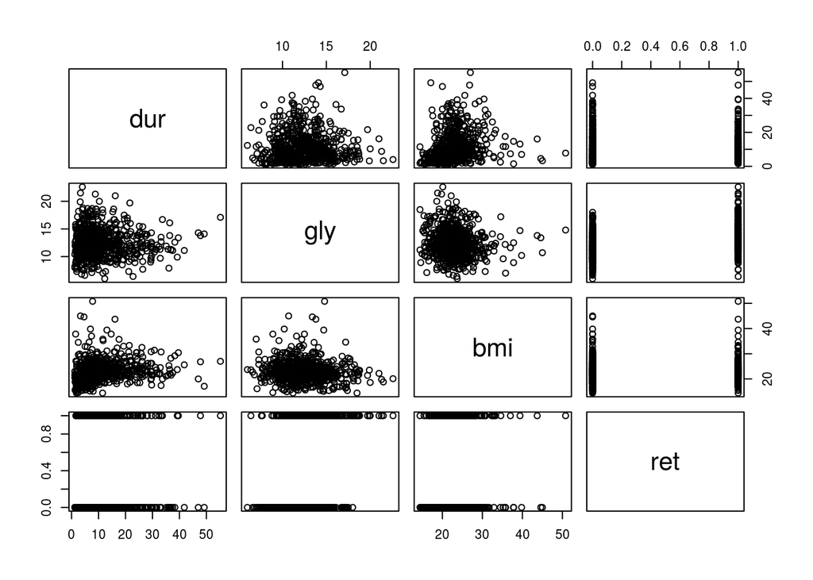

```r
library(testGam)
library(mgcv)
data("wesdr")

pairs(wesdr)
```

2. Fit logistic model with all interactions

```r
k = 10
fit1 <- gam(ret ~ ti(dur,k=k) + ti(gly,k=k) + ti(bmi,k=k) + ti(dur,gly,k=k)+
                  ti(dur,bmi,k=k) + ti(gly,bmi,k=k),
            data=wesdr,
            family=binomial())

summary(fit1)
```

```
##
## Family: binomial
## Link function: logit
##
## Formula:
## ret ~ ti(dur, k = k) + ti(gly, k = k) + ti(bmi, k = k) + ti(dur,
##     gly, k = k) + ti(dur, bmi, k = k) + ti(gly, bmi, k = k)
##
## Parametric coefficients:
##             Estimate Std. Error z value Pr(>|z|)
## (Intercept)   0.6142     0.4333   1.417    0.156
##
## Approximate significance of smooth terms:
##                edf Ref.df Chi.sq  p-value
## ti(dur)      3.783  4.632 14.518  0.00974 **
## ti(gly)      8.946  8.996 80.540 1.23e-13 ***
## ti(bmi)      2.400  3.047  7.653  0.05441 .
## ti(dur,gly)  1.000  1.001  0.161  0.68887
## ti(dur,bmi) 11.273 13.413 14.051  0.38886
## ti(gly,bmi)  2.287 56.000  5.196  0.06944 .
## ---
## Signif. codes:  0 '***' 0.001 '**' 0.01 '*' 0.05 '.' 0.1 ' ' 1
##
## R-sq.(adj) =  0.238   Deviance explained = 22.7%
## UBRE = 0.14086  Scale est. = 1         n = 669
```

None of the interactions seem very important. We now plot all effects

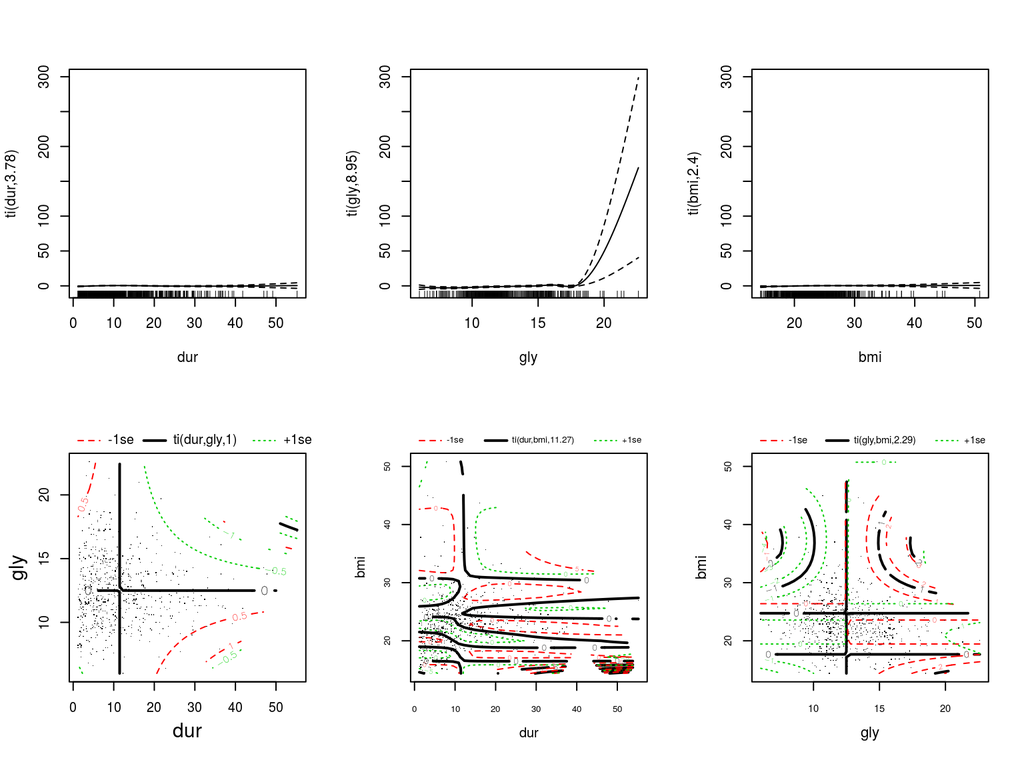

```r
plot(fit1, pages = 1)
```

The interaction between `dur` and `bmi` seems to be overfitting quite horribly, and the marginal effect of of `gly` is exploding for `gly > 17`. This does not look good.

3. Refit using REML for smoothing parameter selection

```r
fit2 <- gam(ret ~ ti(dur,k=k) + ti(gly,k=k) + ti(bmi,k=k) + ti(dur,gly,k=k)+
                  ti(dur,bmi,k=k) + ti(gly,bmi,k=k),
            data=wesdr,
            family=binomial(), method = "REML")

summary(fit2)
```

```
##
## Family: binomial
## Link function: logit
##
## Formula:
## ret ~ ti(dur, k = k) + ti(gly, k = k) + ti(bmi, k = k) + ti(dur,
##     gly, k = k) + ti(dur, bmi, k = k) + ti(gly, bmi, k = k)
##
## Parametric coefficients:
##             Estimate Std. Error z value Pr(>|z|)
## (Intercept)  -0.4027     0.0952   -4.23 2.34e-05 ***
## ---
## Signif. codes:  0 '***' 0.001 '**' 0.01 '*' 0.05 '.' 0.1 ' ' 1
##
## Approximate significance of smooth terms:
##               edf Ref.df Chi.sq p-value
## ti(dur)     3.799  4.663 16.353 0.00473 **
## ti(gly)     1.000  1.000 83.499 < 2e-16 ***
## ti(bmi)     2.927  3.664 10.134 0.03014 *
## ti(dur,gly) 1.000  1.001  0.487 0.48538
## ti(dur,bmi) 2.768  4.121  2.453 0.66791
## ti(gly,bmi) 1.262 80.000  4.286 0.03011 *
## ---
## Signif. codes:  0 '***' 0.001 '**' 0.01 '*' 0.05 '.' 0.1 ' ' 1
##
## R-sq.(adj) =  0.223   Deviance explained = 19.1%
## -REML = 373.25  Scale est. = 1         n = 669
```

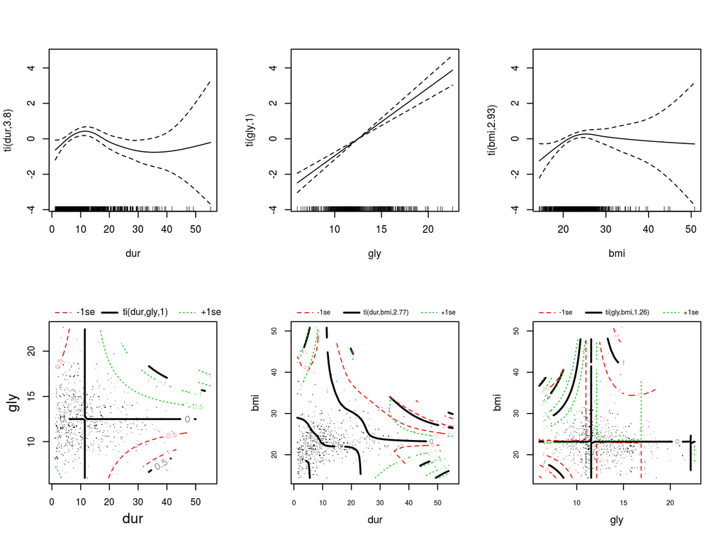

```r
plot(fit2, pages = 1)
```

4. Now we try to select the effects by penalising also their parametric part

```r
fit3 <- gam(ret ~ ti(dur,k=k) + ti(gly,k=k) + ti(bmi,k=k) + ti(dur,gly,k=k)+
                  ti(dur,bmi,k=k) + ti(gly,bmi,k=k),
            data=wesdr,
            family=binomial(),
            select = TRUE, method = "REML")

summary(fit3)
```

```
##
## Family: binomial
## Link function: logit
##
## Formula:
## ret ~ ti(dur, k = k) + ti(gly, k = k) + ti(bmi, k = k) + ti(dur,
##     gly, k = k) + ti(dur, bmi, k = k) + ti(gly, bmi, k = k)
##
## Parametric coefficients:
##             Estimate Std. Error z value Pr(>|z|)
## (Intercept) -0.40280    0.09017  -4.467 7.93e-06 ***
## ---
## Signif. codes:  0 '***' 0.001 '**' 0.01 '*' 0.05 '.' 0.1 ' ' 1
##
## Approximate significance of smooth terms:
##                   edf Ref.df Chi.sq  p-value
## ti(dur)     2.9865146      9 16.684 0.000245 ***
## ti(gly)     0.9892354      9 88.022  < 2e-16 ***
## ti(bmi)     2.0053045      9 11.768 0.000786 ***
## ti(dur,gly) 0.0003153     81  0.000 0.677779
## ti(dur,bmi) 0.0004622     81  0.000 0.488533
## ti(gly,bmi) 1.4365672     79  5.453 0.018372 *
## ---
## Signif. codes:  0 '***' 0.001 '**' 0.01 '*' 0.05 '.' 0.1 ' ' 1
##
## R-sq.(adj) =  0.223   Deviance explained = 18.5%
## -REML = 384.68  Scale est. = 1         n = 669
```

Notice that the effective degrees of freedom of the first two interaction are close to zero while, without `select = TRUE`, they could not go below 1 (the linear component of the interaction, which is unpenalised). In fact, we see that the second interaction is now almost flat

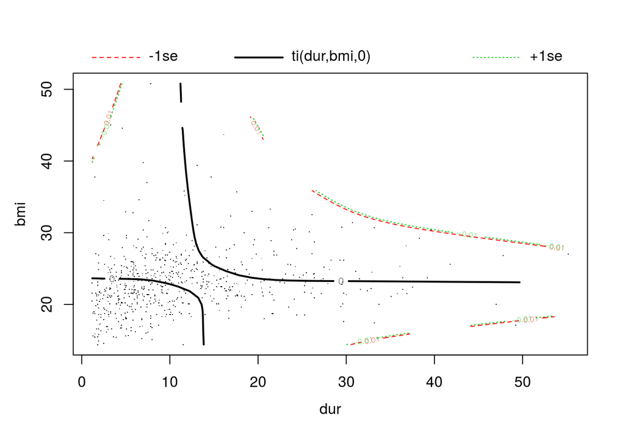

```r
plot(fit3, select = 5)
```

5. Fit simplified model and look at the effects:

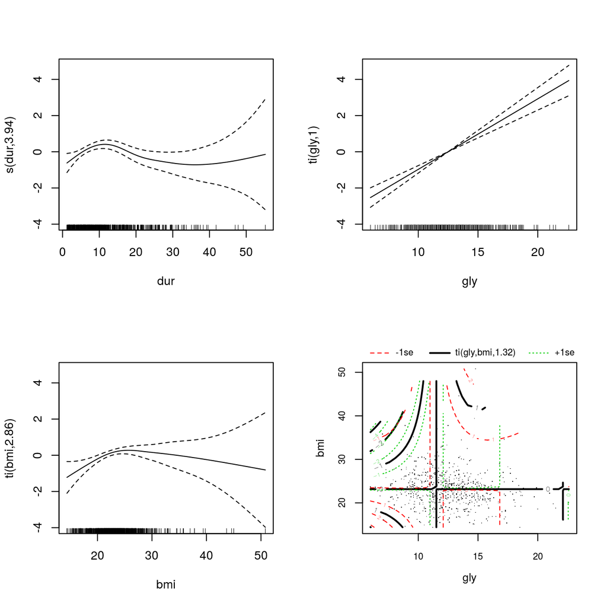

```r
fit4 <- gam(ret ~ s(dur, k=10) + ti(gly, k=10) + ti(bmi, k=10) + ti(gly, bmi,k = 10),
            data=wesdr,
            family=binomial(), method = "REML")

plot(fit4, pages = 1)
```

Compare with model with simple linear interaction

```r
fit5 <- gam(ret ~ s(dur, k=10) + ti(gly, k=10) + ti(bmi, k=10) + I(gly * bmi),
            data=wesdr,
            family=binomial(), method = "REML")

AIC(fit4, fit5)
```

```
##            df      AIC
## fit4 12.20862 764.4870
## fit5 11.02373 766.6095
```

The tensor interaction seems slightly better.